# Project Pitch: r/wallstreetbets

5/5/2021

## Why r/wallstreetbets (r/wsb)?

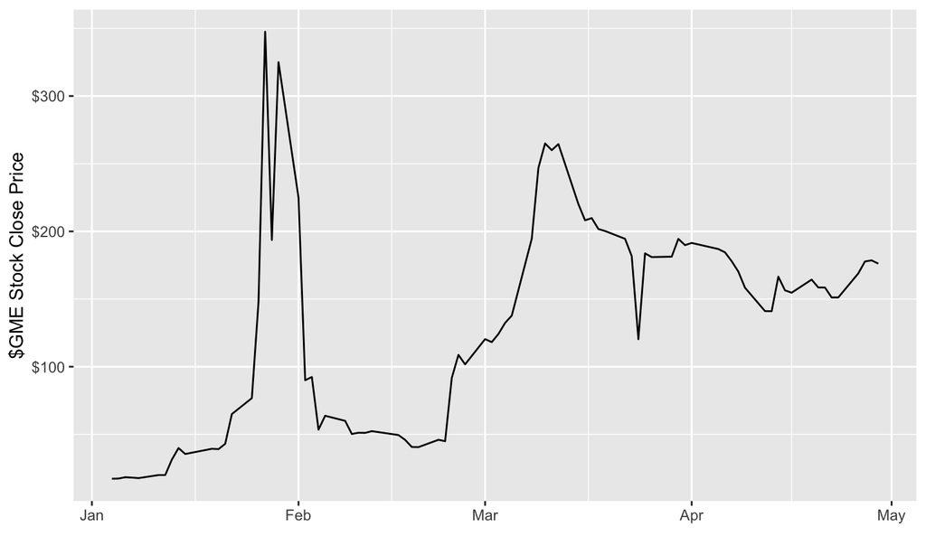

## What is r/wallstreetbets?

[figure not shown]

r/wallstreetbets homepage

## What’s the goal?

**Identify stocks whose prices are likely to be influenced by users on r/wsb, and whether these stocks will gain or lose value.**

## The Data

- I used the Pushshift API to retrieve data scraped from Reddit.
- I used the `yfinance` Python library to get stock price data, which is being pulled from the Yahoo Finance API.
- Real time posts appear to mainly react to stock price movements. I focused the comments to the “What Are Your Moves Tomorrow” moderator posts.

## The Data

```
## # A tibble: 90,029 x 5
##    author      body                    created_utc         id    score
##    <chr>       <chr>                   <dttm>              <chr> <dbl>
##  1 silas_p_si… You’d think I’m into B… 2021-04-22 16:00:30 gvhf…     8
##  2 HotLava35   Picking up the late sh… 2021-04-22 16:00:38 gvhf…     2
##  3 watchshoe   Fun day, would do it a… 2021-04-22 16:00:50 gvhf…     2
##  4 bullishSta… Buying more GME 🚀💎    2021-04-22 16:00:59 gvhf…     5
##  5 SaveTheAles Guys calm down biden d… 2021-04-22 16:01:02 gvhf…    77
##  6 SENAcucks   I need a cigarette      2021-04-22 16:01:05 gvhf…     7
##  7 Profession… Portfolio down 74% tod… 2021-04-22 16:01:11 gvhf…   105
##  8 futurefail… Praying for AMC to $9   2021-04-22 16:01:13 gvhf…    -3
##  9 400Jordan   Cashing out SNAP after… 2021-04-22 16:01:22 gvhf…     1
## 10 InSearchof… Worst day for stocks a… 2021-04-22 16:01:26 gvhf…     5
## # … with 90,019 more rows
```

## What Has Been Done?

- Used the `tidytext` package to tokenize the comment text into words.
- Number of unique comments containing a particular stock and their average score are promising predictors.
- Removed standard English dictionary words from stock ticker options. ($GOOD, $CAN, $GO, $NEXT, $PLAY, etc.)
- Using standard sentiment analysis dictionaries not promising.

## Preliminary Results

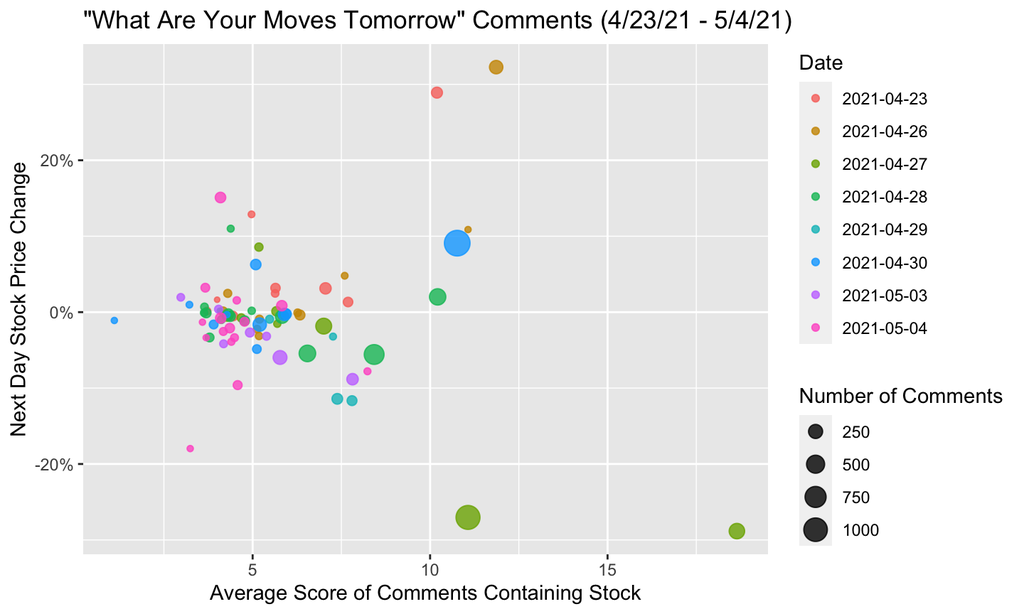

## Where Do We Go From Here?

- Include additional stock variables (r/wsb buying power, overall market conditions).
- Custom sentiment dictionary.
- Build a crosswalk between ticker symbols and commonly used names. (mvis = mavis = microvision)
- Consider data from other types of r/wsb posts.